# Examen Parcial - PARTE N°2

Grupo N° 6 - GeoCódigo

FECHA: 05-08-2021

# PARTE 2 - Se puede usas librerías

**1. A partir del siguiente *conjunto de datos*, se describen las variables:**

```r
library(tidyverse)
library(dplyr)
library(ggplot2)
```

*Cargando el conjunto de datos*

```r
datos <- read_csv("data/mods_clima_uh.csv")
```

```r
(datos <- datos %>%
  filter(
    uh_name == "Cuenca Tumbes"
  ) %>%
  select(
    bh_month, everything()
  ) %>%
  mutate(bh_month = sprintf("%1$02d", bh_month)))
```

```
## # A tibble: 48 x 8
##    bh_month  code uh_name       bh_esc      bh_pc  bh_er bh_rh bh_qd
##    <chr>    <dbl> <chr>         <chr>       <dbl>  <dbl> <dbl> <dbl>
##  1 01        1394 Cuenca Tumbes Observado 108.    31.5    34.7  62.1
##  2 02        1394 Cuenca Tumbes Observado 182.    50.8    66.0 138.
##  3 03        1394 Cuenca Tumbes Observado 228.    79.1    98.2 190.
##  4 04        1394 Cuenca Tumbes Observado 199.    66.5   112.  225.
##  5 05        1394 Cuenca Tumbes Observado  39.0   23.5    74.6 157.
##  6 06        1394 Cuenca Tumbes Observado   8.39   7.10   46.1 102.
##  7 07        1394 Cuenca Tumbes Observado   1.11   1.89   33.3  69.6
##  8 08        1394 Cuenca Tumbes Observado   0.621  0.927  23.7  48.1
##  9 09        1394 Cuenca Tumbes Observado   2.07   2.10   16.6  33.8
## 10 10        1394 Cuenca Tumbes Observado  13.4   10.5    13.4  25.3
## # ... with 38 more rows
```

*Visualizamos los nombres de los escenarios*

```r
table(datos$bh_esc)
```

```
##
## ACCESS 1.0 HadGEM2-ES MPI-ESM-LR  Observado
##         12         12         12         12
```

Se solicita lo sgte:

**(a) Calcular la Precipitación acumulada anual (Valores observados) para la cuenca asignada.**

*Trabajamos con la Cuenca Tumbes*

```r
(observado <- datos %>%
  group_by(bh_esc) %>%
  summarise(
    bh_pc = sum(bh_pc, na.rm = T)
  ) %>%
  filter(bh_esc == "Observado"))
```

```
## # A tibble: 1 x 2
##   bh_esc    bh_pc
##   <chr>     <dbl>
## 1 Observado  852.
```

- Los datos extraidos mediante el filtro al conjunto de datos para la Cuenca Tumbes y los escenarios.
- Los datos Observados nos muestran que la data corresponde a un solo año, sin datos faltantes ni missing values.Por ende se precide de realizar la comprobacion de la cantidad de datos y existencia de valores NA.
- La precipitación acumulada anual observada para la Cuenca Tumbes es de 852 mm.

**(b) Calcular el porcentaje de sesgo (%.PBIAS) de los escenarios climáticos (ACCESS, HADGEM2 , MPI) respecto a los datos observados para cada mes (enero - diciembre) de cada variable, para la cuenca asignada.**

*Filtrando cada modelo*

```r
models <- c("ACCESS 1.0", "HadGEM2-ES", "MPI-ESM-LR", "Observado")
model <- data.frame(month.abb)

for (i in 1:4) {
  valor <- datos %>%
    filter(bh_esc == models[i]) %>%
    select(bh_pc)

  model <- cbind(model, valor)
}
colnames(model) <- c("meses", "ACCESS 1.0", "HadGEM2-ES", "MPI-ESM-LR", "Observado")
model
```

```
##    meses  ACCESS 1.0 HadGEM2-ES  MPI-ESM-LR   Observado
## 1    Jan 189.2583333 105.837346  88.1949074 107.7222222
## 2    Feb 225.4086420 220.649691 233.2955247 181.9952160
## 3    Mar 292.5112654 243.724383 229.8470679 227.9540123
## 4    Apr 218.3214506 227.314815 147.6195988 199.0138889
## 5    May  32.2145062  66.484877  33.0645062  38.9842593
## 6    Jun   7.5817901  11.830093   4.0831790   8.3944444
## 7    Jul   2.6816358   3.530093   0.8430556   1.1098765
## 8    Aug   0.4733025   0.833642   0.4631173   0.6212963
## 9    Sep   2.0527778   1.823611   1.5904321   2.0683642
## 10   Oct  24.0435185  13.033488  19.2908951  13.3933642
## 11   Nov  28.2643519  26.832253  37.1898148  28.1310185
## 12   Dec  49.8966049  47.191204  43.3859568  42.4638889
```

**Ahora realizamos el sesgo para cada uno de los modelos**

```r
(sesgo <- model %>%
  mutate(
    SESGO_ACCESS = (abs(`ACCESS 1.0` - Observado)/Observado)*100,
    SESGO_HADGEM2 = (abs(`HadGEM2-ES` - Observado)/Observado)*100,
    SESGO_MPI = (abs(`MPI-ESM-LR` - Observado)/Observado)*100
  ) %>%
   select(meses, SESGO_ACCESS, SESGO_HADGEM2, SESGO_MPI))
```

```
##    meses SESGO_ACCESS SESGO_HADGEM2 SESGO_MPI
## 1    Jan   75.6910779      1.749756 18.127471
## 2    Feb   23.8541578     21.239281 28.187724
## 3    Mar   28.3202969      6.918225  0.830455
## 4    Apr    9.7016152     14.220578 25.824474
## 5    May   17.3653501     70.542875 15.184983
## 6    Jun    9.6808589     40.927642 51.358556
## 7    Jul  141.6156841    218.061735 24.040601
## 8    Aug   23.8201689     34.177844 25.459513
## 9    Sep    0.7535626     11.833172 23.106767
## 10   Oct   79.5181417      2.686977 44.033230
## 11   Nov    0.4739726      4.616845 32.202162
## 12   Dec   17.5036160     11.132553  2.171417
```

**(c) De la pregunta anterior, ¿Cuál es el escenario climático más preciso? Fundamente su respuesta.**

```r
(preciso_model<- sesgo %>%
  summarise(
    SESGO_ACCESS = mean(SESGO_ACCESS),
    SESGO_HADGEM2 = mean(SESGO_HADGEM2),
    SESGO_MPI = mean(SESGO_MPI)
  ))
```

```
##   SESGO_ACCESS SESGO_HADGEM2 SESGO_MPI
## 1     35.69154      36.50896  24.21061
```

*Graficamos*

[figure not shown]

```r
grafico <- read_csv("data/mods_clima_uh.csv") %>%
  filter(uh_name == "Cuenca Tumbes" & bh_esc == "Observado")

ggplot(grafico, mapping = aes(x = bh_month))+
  geom_line(mapping = aes(y = bh_er, color = "Access"))+
  geom_line(mapping = aes(y = bh_rh, color = "HADGEM2"))+
  geom_line(mapping = aes(y = bh_qd, color = "MPI"))+
  geom_line(mapping = aes(y = bh_pc, color = "Observado"),
            size = 1.1)+
  labs(colour = "Modelo",
       x = "Mes",
       y = "Precipitación (mm)")+
  scale_colour_manual("",
                      breaks = c("Access","HADGEM2","MPI","Observado"),
                      values = c("red","green","orange","blue"))
```

*Comentario:* El escenario climático más preciso es el modelo “MPI-ESM-LR”, porque el sesgo de los datos es menor en comparación con los demás modelos, por lo tanto los datos de este modelo son más confiables.

**(d) Graficar, con *ggplot2*, la precipitación (enero a diciembre) observada y modelos climáticos.**

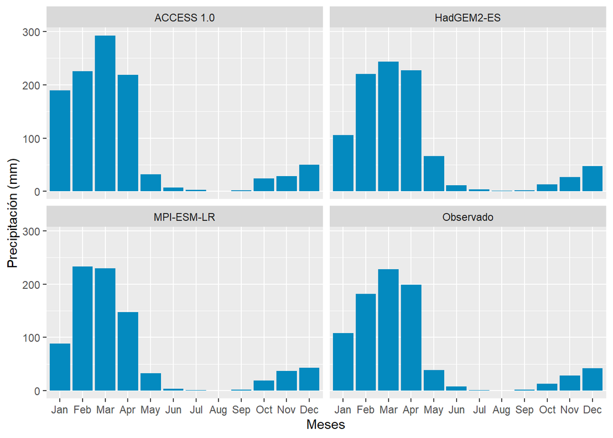

```r
ggplot(datos) +
  geom_bar(mapping = aes(x = bh_month, y = bh_pc), stat = "identity", fill = "#048ABF") +
  facet_wrap(~bh_esc) +
  scale_x_discrete(labels = month.abb)+
  labs(x = "Meses", y = "Precipitación (mm)")
```